# Lab 6

## Set Up

Setup packages & Load in the cleaned data from the USCbiostats/data-science-data repository.

```r
# Read in Medical Transcriptions
library(readr)
library(dplyr)
mt_samples <- read_csv("https://raw.githubusercontent.com/USCbiostats/data-science-data/master/00_mtsamples/mtsamples.csv")
mt_samples <- mt_samples |>
  select(description, medical_specialty, transcription)

head(mt_samples)
```

```
# A tibble: 6 × 3
  description                                    medical_specialty transcription
  <chr>                                          <chr>             <chr>
1 A 23-year-old white female presents with comp… Allergy / Immuno… "SUBJECTIVE:…
2 Consult for laparoscopic gastric bypass.       Bariatrics        "PAST MEDICA…
3 Consult for laparoscopic gastric bypass.       Bariatrics        "HISTORY OF …
4 2-D M-Mode. Doppler.                           Cardiovascular /… "2-D M-MODE:…
5 2-D Echocardiogram                             Cardiovascular /… "1.  The lef…
6 Morbid obesity.  Laparoscopic antecolic anteg… Bariatrics        "PREOPERATIV…
```

## Question 1

Use the count() function from dplyr to figure out how many different categories we have in the data. Are these categories related? Overlapping? Evenly distributed?

```r
# What specialties do we have?
mt_samples %>%
  count(medical_specialty, sort = TRUE)
```

```
# A tibble: 40 × 2
   medical_specialty                 n
   <chr>                         <int>
 1 Surgery                        1103
 2 Consult - History and Phy.      516
 3 Cardiovascular / Pulmonary      372
 4 Orthopedic                      355
 5 Radiology                       273
 6 General Medicine                259
 7 Gastroenterology                230
 8 Neurology                       223
 9 SOAP / Chart / Progress Notes   166
10 Obstetrics / Gynecology         160
# ℹ 30 more rows
```

## Question 2

Tokenize the the words in the transcription column Count the number of times each token appears. Visualize the top 20 most frequent words

# Summary

Explain what we see from this result. Does it makes sense? What insights (if any) do we get?

- The top 20 most frequent words are dominated by common stop words such as “the,” “and,” “to,” “of,” and “in”. A few clinically relevant words like “patient,” “right,” and “no” also appear, reflecting typical phrasing in medical documentation. However, the insights at this stage are limited because stop words overwhelm the medical vocabulary.

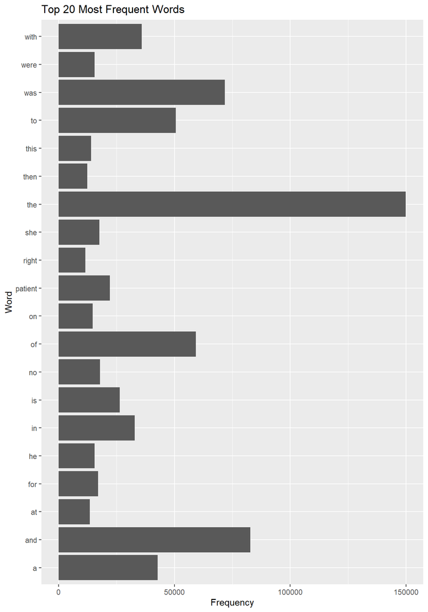

```r
# Tokenize Data
library(tidytext)
tokens <- mt_samples %>%
  unnest_tokens(word, transcription)

# Count word frequency
word_counts <- tokens %>%
  count(word, sort = TRUE)

# Visualize the top 20 most frequent words
library(dplyr)
library(ggplot2)
library(tidytext)

mt_samples %>%
  unnest_tokens(token, transcription) %>%
  count(token) %>%
  top_n(20, n) %>%
  ggplot(aes(n, token)) +
  geom_col() +
  labs(title = "Top 20 Most Frequent Words",
       x = "Frequency",
       y = "Word")
```

## Question 3

Re-do the visualization but remove stop words before making it Bonus points if you remove numbers as well.

# Summary

What do we see now that we have removed stop words? Does it give us a better idea of what the text is about?

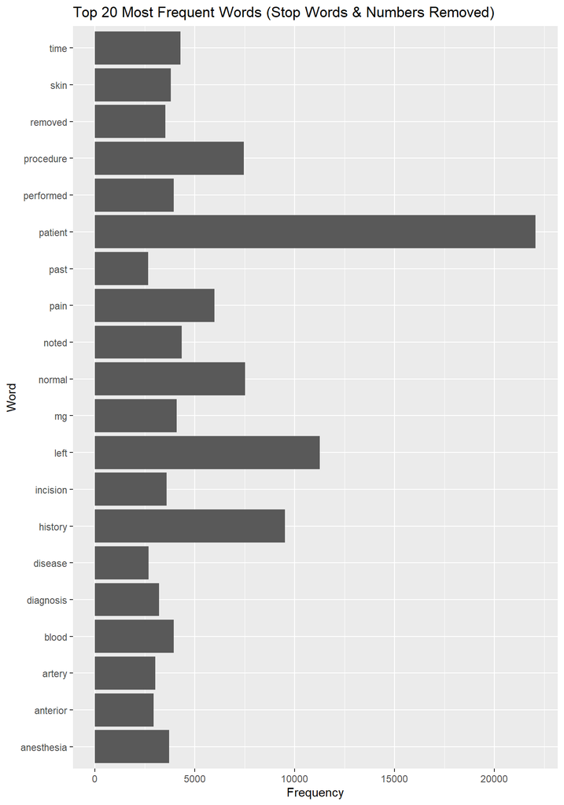

```r
library(tidytext)
library(dplyr)
library(stringr)
library(ggplot2)

 # Remove stop words
clean_tokens <- mt_samples %>%
  unnest_tokens(word, transcription) %>%
  anti_join(stop_words, by = c("word"))|>
  count(word, sort = TRUE)

# Remove numbers
clean_tokens <- clean_tokens %>%
  filter(!str_detect(word, "^[0-9]+$"))

# Visualize top 20
clean_tokens %>%
  top_n(20, n) %>%
  ggplot(aes(n, word)) +
  geom_col() +
  labs(title = "Top 20 Most Frequent Words (Stop Words & Numbers Removed)",
       x = "Frequency",
       y = "Word")
```

## Question 4

Repeat question 2, but this time tokenize into bi-grams. How does the result change if you look at tri-grams?

[figure not shown]

```r
library(dplyr)
library(tidytext)
library(stringr)
library(ggplot2)

# Create bi-grams
bigrams <- mt_samples %>%
  unnest_tokens(bigram, transcription, token = "ngrams", n = 2)

# Remove bi‑grams containing stop words
bigrams <- mt_samples %>%
  unnest_tokens(word, transcription) %>%
  anti_join(stop_words, by = c("word"))|>
  count(word, sort = TRUE)

# Remove bi-grams containing numbers
bigrams <- bigrams %>%
  filter(!str_detect(word, "^[0-9]+$"))

# Visualize top 20 bi‑grams
bigrams %>%
  top_n(20, n) %>%
  ggplot(aes(n, word)) +
  geom_col() +
  labs(title = "Top 20 Most Frequent Bi-grams (Cleaned)",
       x = "Frequency",
       y = "Bi-gram")
```

[figure not shown]

```r
# Create tri-grams
trigrams <- mt_samples %>%
  unnest_tokens(trigram, transcription, token = "ngrams", n = 3)

# Remove bi‑grams containing stop words
trigrams <- mt_samples %>%
  unnest_tokens(word, transcription) %>%
  anti_join(stop_words, by = c("word"))|>
  count(word, sort = TRUE)

# Remove bi-grams containing numbers
trigrams <- trigrams %>%
  filter(!str_detect(word, "^[0-9]+$"))

# Visualize top 20 bi‑grams
trigrams %>%
  top_n(20, n) %>%
  ggplot(aes(n, word)) +
  geom_col() +
  labs(title = "Top 20 Most Frequent Tri-grams (Cleaned)",
       x = "Frequency",
       y = "Tri-gram")
```

## Question 5

Using the results you got from Question 4, pick a word and count the words that appear before and after it.

```r
library(dplyr)
library(tidyr)

# ReCreate Bigrams
bigrams <- mt_samples %>%
  unnest_tokens(bigram, transcription, token = "ngrams", n = 2)

# Split bi‑grams into two words
bigrams_split <- bigrams %>%
  separate(bigram, into = c("word1", "word2"), sep = " ")

# Words that appear BEFORE “pain”
bigrams_split %>%
  filter(word2 == "pain") %>%
  count(word1, sort = TRUE)
```

```
# A tibble: 326 × 2
   word1         n
   <chr>     <int>
 1 chest       707
 2 back        561
 3 abdominal   461
 4 the         361
 5 neck        218
 6 for         178
 7 of          163
 8 and         130
 9 his         127
10 her         115
# ℹ 316 more rows
```

```r
# Words that appear AFTER "pain"
bigrams_split %>%
  filter(word1 == "pain") %>%
  count(word2, sort = TRUE)
```

```
# A tibble: 537 × 2
   word2           n
   <chr>       <int>
 1 and           500
 2 in            323
 3 or            255
 4 with          231
 5 is            199
 6 he            191
 7 the           185
 8 she           165
 9 no            147
10 medications   103
# ℹ 527 more rows
```

## Question 6

Which words are most used in each of the specialties? You can use group_by() and top_n() from dplyr to have the calculations be done within each specialty. Remember to remove stop words. What are the 5 most-used words for each specialty?

```r
library(dplyr)
library(tidytext)
library(stringr)

# Retokenize Dataset w/ specialties
tokens_specialty <- mt_samples %>%
  unnest_tokens(word, transcription)

# Remove stop words
tokens_specialty <- tokens_specialty %>%
  anti_join(stop_words, by = "word")

# Remove numbers
tokens_specialty <- tokens_specialty %>%
  filter(!str_detect(word, "^[0-9]+$"))

head(tokens_specialty)
```

```
# A tibble: 6 × 3
  description                                            medical_specialty word
  <chr>                                                  <chr>             <chr>
1 A 23-year-old white female presents with complaint of… Allergy / Immuno… subj…
2 A 23-year-old white female presents with complaint of… Allergy / Immuno… white
3 A 23-year-old white female presents with complaint of… Allergy / Immuno… fema…
4 A 23-year-old white female presents with complaint of… Allergy / Immuno… comp…
5 A 23-year-old white female presents with complaint of… Allergy / Immuno… alle…
6 A 23-year-old white female presents with complaint of… Allergy / Immuno… alle…
```

```r
# Count words per specialty
word_counts_specialty <- tokens_specialty %>%
  group_by(medical_specialty, word) %>%
  summarise(n = n(), .groups = "drop")

head(word_counts_specialty)
```

```
# A tibble: 6 × 3
  medical_specialty    word      n
  <chr>                <chr> <int>
1 Allergy / Immunology 16.5      1
2 Allergy / Immunology 6h        1
3 Allergy / Immunology 97.1      1
4 Allergy / Immunology 97.8      1
5 Allergy / Immunology 98.4      1
6 Allergy / Immunology 98.7      1
```

```r
# Get TOP 5 words per specialty
top5_words_specialty <- word_counts_specialty %>%
  group_by(medical_specialty) %>%
  top_n(5, n)

head(top5_words_specialty)
```

```
# A tibble: 6 × 3
# Groups:   medical_specialty [1]
  medical_specialty    word          n
  <chr>                <chr>     <int>
1 Allergy / Immunology allergies    21
2 Allergy / Immunology history      38
3 Allergy / Immunology nasal        13
4 Allergy / Immunology noted        23
5 Allergy / Immunology past         13
6 Allergy / Immunology patient      22
```

## Question 7

Find your own insight in the data:

See if certain words are used more in some specialties than others- resolved using TF - IDF

```r
# Set Up Data set
tokens_specialty <- mt_samples %>%
  unnest_tokens(word, transcription) %>%
  anti_join(stop_words, by = "word") %>%
  filter(!str_detect(word, "^[0-9]+$")) %>%
  count(medical_specialty, word, sort = TRUE)

# Bind the two Data sets
tfidf_specialty <- top5_words_specialty %>%
  bind_tf_idf(word, medical_specialty, n)

# Top 5 most frequent words (removing ties)
top5_tfidf <- tfidf_specialty %>%
  group_by(medical_specialty) %>%
  slice_max(tf_idf, n = 5)

head(tokens_specialty)
```

```
# A tibble: 6 × 3
  medical_specialty          word          n
  <chr>                      <chr>     <int>
1 Surgery                    patient    4855
2 Surgery                    left       3263
3 Surgery                    procedure  3243
4 Consult - History and Phy. patient    3046
5 Consult - History and Phy. history    2820
6 Orthopedic                 patient    1711
```

```r
head(tfidf_specialty)
```

```
# A tibble: 6 × 6
# Groups:   medical_specialty [1]
  medical_specialty    word          n    tf    idf  tf_idf
  <chr>                <chr>     <int> <dbl>  <dbl>   <dbl>
1 Allergy / Immunology allergies    21 0.162 3.69   0.596
2 Allergy / Immunology history      38 0.292 0.644  0.188
3 Allergy / Immunology nasal        13 0.1   3.00   0.300
4 Allergy / Immunology noted        23 0.177 3.00   0.530
5 Allergy / Immunology past         13 0.1   3.69   0.369
6 Allergy / Immunology patient      22 0.169 0.0513 0.00868
```

```r
head(top5_tfidf)
```

```
# A tibble: 6 × 6
# Groups:   medical_specialty [2]
  medical_specialty    word          n    tf   idf tf_idf
  <chr>                <chr>     <int> <dbl> <dbl>  <dbl>
1 Allergy / Immunology allergies    21 0.162 3.69   0.596
2 Allergy / Immunology noted        23 0.177 3.00   0.530
3 Allergy / Immunology past         13 0.1   3.69   0.369
4 Allergy / Immunology nasal        13 0.1   3.00   0.300
5 Allergy / Immunology history      38 0.292 0.644  0.188
6 Autopsy              inch         59 0.208 3.69   0.766
```